# Final Project

Data Science for Biologists, Spring 2021

Vinny Varghese

## Introduction

**The data set that I chose was from kaggle.com, and it is called heart.csv. This dataset analyzes heart attacks and some of the factors that goes into predicting if a person will have a heart attack. Since I want to go into the medical field, this data set caught my eye. If using the techniques we learned in class this year can do an accurate job at predicting heart attacks, it will bode well for the future of the medical field.**

This is the link to the [Heart Attack Dataset](https://www.kaggle.com/rashikrahmanpritom/heart-attack-analysis-prediction-dataset)

```r
heart <- read_csv("varghese_heart.csv")
heart
```

```
## # A tibble: 303 x 14
##      age   sex    cp trtbps  chol   fbs restecg thalachh  exng oldpeak   slp
##    <dbl> <dbl> <dbl>  <dbl> <dbl> <dbl>   <dbl>    <dbl> <dbl>   <dbl> <dbl>
##  1    63     1     3    145   233     1       0      150     0     2.3     0
##  2    37     1     2    130   250     0       1      187     0     3.5     0
##  3    41     0     1    130   204     0       0      172     0     1.4     2
##  4    56     1     1    120   236     0       1      178     0     0.8     2
##  5    57     0     0    120   354     0       1      163     1     0.6     2
##  6    57     1     0    140   192     0       1      148     0     0.4     1
##  7    56     0     1    140   294     0       0      153     0     1.3     1
##  8    44     1     1    120   263     0       1      173     0     0       2
##  9    52     1     2    172   199     1       1      162     0     0.5     2
## 10    57     1     2    150   168     0       1      174     0     1.6     2
## # … with 293 more rows, and 3 more variables: caa <dbl>, thall <dbl>,
## #   output <dbl>
```

```r
dplyr::glimpse(heart)
```

```
## Rows: 303
## Columns: 14
## $ age      <dbl> 63, 37, 41, 56, 57, 57, 56, 44, 52, 57, 54, 48, 49, 64, 58, …
## $ sex      <dbl> 1, 1, 0, 1, 0, 1, 0, 1, 1, 1, 1, 0, 1, 1, 0, 0, 0, 0, 1, 0, …
## $ cp       <dbl> 3, 2, 1, 1, 0, 0, 1, 1, 2, 2, 0, 2, 1, 3, 3, 2, 2, 3, 0, 3, …
## $ trtbps   <dbl> 145, 130, 130, 120, 120, 140, 140, 120, 172, 150, 140, 130, …
## $ chol     <dbl> 233, 250, 204, 236, 354, 192, 294, 263, 199, 168, 239, 275, …
## $ fbs      <dbl> 1, 0, 0, 0, 0, 0, 0, 0, 1, 0, 0, 0, 0, 0, 1, 0, 0, 0, 0, 0, …
## $ restecg  <dbl> 0, 1, 0, 1, 1, 1, 0, 1, 1, 1, 1, 1, 1, 0, 0, 1, 1, 1, 1, 1, …
## $ thalachh <dbl> 150, 187, 172, 178, 163, 148, 153, 173, 162, 174, 160, 139, …
## $ exng     <dbl> 0, 0, 0, 0, 1, 0, 0, 0, 0, 0, 0, 0, 0, 1, 0, 0, 0, 0, 0, 0, …
## $ oldpeak  <dbl> 2.3, 3.5, 1.4, 0.8, 0.6, 0.4, 1.3, 0.0, 0.5, 1.6, 1.2, 0.2, …
## $ slp      <dbl> 0, 0, 2, 2, 2, 1, 1, 2, 2, 2, 2, 2, 2, 1, 2, 1, 2, 0, 2, 2, …
## $ caa      <dbl> 0, 0, 0, 0, 0, 0, 0, 0, 0, 0, 0, 0, 0, 0, 0, 0, 0, 0, 0, 2, …
## $ thall    <dbl> 1, 2, 2, 2, 2, 1, 2, 3, 3, 2, 2, 2, 2, 2, 2, 2, 2, 2, 2, 2, …
## $ output   <dbl> 1, 1, 1, 1, 1, 1, 1, 1, 1, 1, 1, 1, 1, 1, 1, 1, 1, 1, 1, 1, …
```

## Question 1

#### According to healthline.com, “As you age, the vascular system changes. This includes your heart and blood vessels. In the blood vessels, there’s a reduction in elastic tissue in your arteries, causing them to become stiffer and less compliant. As a result your blood pressure increases.” Knowing this information, can this same knowledge be applied for the variable of resting blood pressure in this dataset?(Does resting blood pressure increase as you get older?)

### Methods

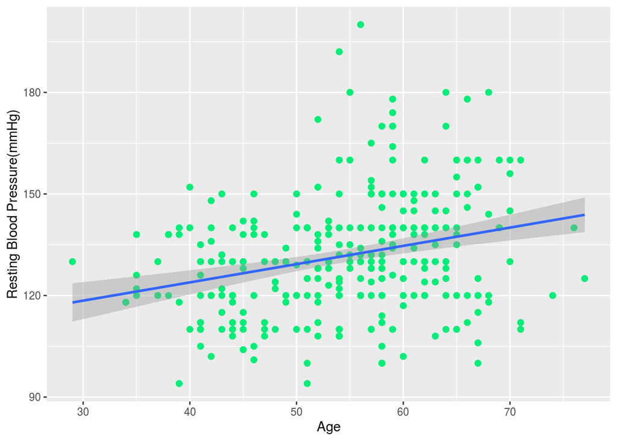

```r
heart %>%
  select(age, trtbps) %>% #use select to keep only age and resting blood pressure to find the relationship

ggplot() +
  aes(x = age, y = trtbps) + #make age the x variable and trtbps the y variable
  geom_point(size = 2,
             color = "springgreen2") + #geom_point should be used for the wide variety of points in the data and make it a size that can be visibly seen
  geom_smooth(method = lm) + #use geom_smooth to have a line of best fit to show the overall strength of the relationship between the two variables
  labs(x = "Age", y = "Resting Blood Pressure(mmHg)")
```

## Question 2

#### Does this dataset show a decrease in maximum heart rate as age increases?

### Methods

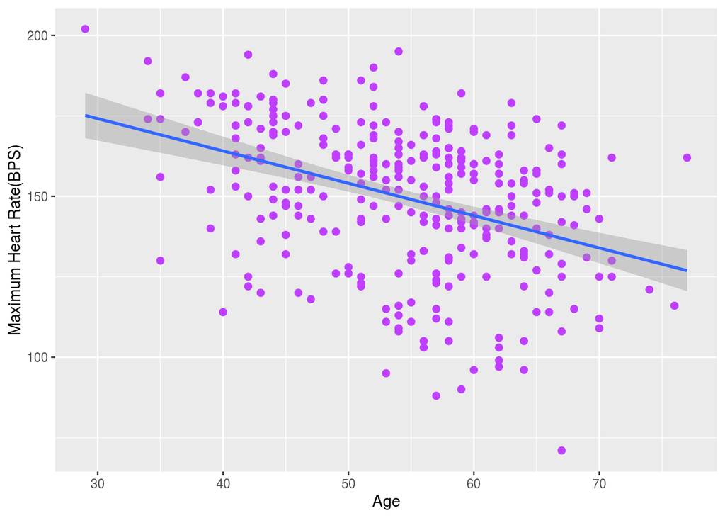

```r
heart %>%
  select(age, thalachh) %>% #make sure to keep only the age and the maximum heart rate(thalachh)

  ggplot(aes(x = age, y = thalachh)) + #age is the independent variable(x) and we are trying to see how max heart rate changes over time(y)
  geom_point(size = 2,
             color = "darkorchid1") +
  geom_smooth(method = lm) + #use geom_smooth to get a line of best fit
  labs(x = "Age", y = "Maximum Heart Rate(BPS)")
```

### Answer

This dataset does indeed show that there is a negative relationship between age and maximum heart rate. This confirms the general belief of the relationship of maximum heart rate of each individual over time.

## Question 3

#### Using Linear regression, to what extent does age explain variation in cholesterol? Is there a significant relationship between these variables(use scatterplot)?

### Methods

```r
fitted_model <- lm(chol ~ age, data = heart) #build a linear model with lm and define it

summary(fitted_model) #examine the model output
```

```
##
## Call:
## lm(formula = chol ~ age, data = heart)
##
## Residuals:
##      Min       1Q   Median       3Q      Max
## -123.476  -32.560   -5.745   28.024  302.330
##
## Coefficients:
##             Estimate Std. Error t value Pr(>|t|)
## (Intercept) 179.9675    17.7116  10.161  < 2e-16 ***
## age           1.2194     0.3213   3.795 0.000179 ***
## ---
## Signif. codes:  0 '***' 0.001 '**' 0.01 '*' 0.05 '.' 0.1 ' ' 1
##
## Residual standard error: 50.72 on 301 degrees of freedom
## Multiple R-squared:  0.04566,    Adjusted R-squared:  0.04249
## F-statistic:  14.4 on 1 and 301 DF,  p-value: 0.0001786
```

```r
broom::tidy(fitted_model) #use this to get the main values to evaluate
```

```
## # A tibble: 2 x 5
##   term        estimate std.error statistic  p.value
##   <chr>          <dbl>     <dbl>     <dbl>    <dbl>
## 1 (Intercept)   180.      17.7       10.2  4.77e-21
## 2 age             1.22     0.321      3.79 1.79e- 4
```

```r
modelr::rsquare(fitted_model, heart) #find rsquared value
```

```
## [1] 0.04565827
```

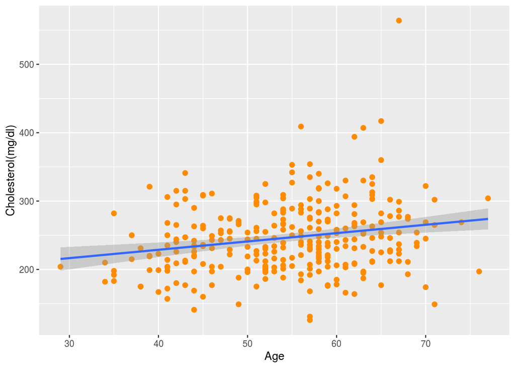

```r
heart %>%
  select(chol, age) %>%

  ggplot(aes(x = age, y = chol)) +
  geom_point(size = 2,
             color = "darkorange") +
  geom_smooth(method = lm) +
  labs(x = "Age", y = "Cholesterol(mg/dl)")
```

## Question 4

#### Which sex has the highest average cholesterol level according to this dataset?

### Methods

[output not shown]

### Have a great summer :)